# Lab Exercises 11

## Question 1

1. Find a 95% interval estimate for the true proportion of votes in the population of Wallsend, for each candidate above , using an MCMC algorithm.

From the lecture notes, with $n = 5796$:
$$p(\theta \mid y) \propto \theta_1^{^{3024}}\,\theta_2^{^{2021}}\,\theta_3^{^{316}}\,(1-\theta_1-\theta_2-\theta_3)^{^{435}}$$

We propose a $beta(1512,1386)$ where $1512 = 3024/2$ and $1386 = 5796/2 - 1512$.

In R:

```r
r1 <- 0.5; r2 <- 0.35; r3 <- 0.05
alpha1 <- 1512; beta1 <- 1386
alpha2 <- 1010.5; beta2 <- 1887.5
alpha3 <- 158; beta3 <- 2740

for (k in 2:10000) {

  rn = rbeta(1,alpha1,beta1)

  alph = 3024 * log(rn) +
         435 * log(1 - rn - r2[k - 1]) -
         3024 * log(r1[k - 1]) -
         435 * log(1 - r1[k - 1] - r2[k - 1] - r3[k - 1])
  alph = alph +
         log(dbeta(r1[k - 1], alpha1, beta1)) -
         log(dbeta(rn, alpha1, beta1))

  if (runif(1) < exp(alph)) {
    r1[k] = rn
    } else {
      r1[k] = r1[k-1]
    }

  rn = rbeta(1,alpha2,beta2)

  alph = 2021 * log(rn) +
         435 * log(1 - rn - r1[k] - r3[k - 1]) -
         2021 * log(r2[k - 1]) -
         435 * log(1 - r1[k - 1] - r2[k - 1] - r3[k - 1])
  alph = alph +
         log(dbeta(r2[k - 1], alpha2, beta2)) -
         log(dbeta(rn, alpha2, beta2))

  if (runif(1) < exp(alph)) {
    r2[k] = rn
    } else {
      r2[k] = r2[k-1]
    }

  rn = rbeta(1,alpha3,beta3)

  alph = 316 * log(rn) +
         435 * log(1 - rn - r1[k] - r2[k]) -
         316 * log(r3[k - 1]) -
         435 * log(1 - r1[k] - r2[k] - r3[k - 1])
  alph = alph +
         log(dbeta(r3[k - 1], alpha3, beta3)) -
         log(dbeta(rn, alpha3, beta3))

  if (runif(1) < exp(alph)) {
    r3[k] = rn
    } else {
      r3[k] = r3[k-1]
    }
}
```

```r
hist(r1)
quantile(r1,c(0.025,0.975))
plot.ts(r1)
hist(r2)
quantile(r2,c(0.025,0.975))
plot.ts(r1)
hist(r2)
quantile(r3,c(0.025,0.975))
plot.ts(r3)
```

```r
y = c(3024,2021,316,435)
r1 = 0.5; r2 = 0.35; r3 = 0.5
for (k in 2:10000) {
  r1[k] = (1 - r2[k - 1] - r3[k - 1]) * rbeta(1, y[1], y[4])
  r2[k] = (1 - r1[k] - r3[k - 1]) * rbeta(1, y[2], y[4])
  r3[k] = (1 - r1[k] - r2[k]) * rbeta(1, y[3], y[4])
}
```

```r
hist(r1)
quantile(r1,c(0.025,0.975))
plot.ts(r1)

hist(r2)
quantile(r2,c(0.025,0.975))
plot.ts(r2)

hist(r2)
quantile(r3,c(0.025,0.975))
plot.ts(r3)

quantile(r1-r2,c(0.025,0.975))
```

2. Find a 95% interval estimate for the ‘Other’ candidates not mentioned above.

```r
quantile(1-r1-r2-r3,c(0.025,0.975))
```

3. Estimate Pr (Labor > Liberal | y) in Wallsend.

```r
mean(r1>r2)
```

4. Find a 95% interval for $\theta_{Labor} - \theta_{Liberal}$.

```r
quantile(r1-r2, c(0.025,0.975))
```

5. Estimate Pr(Other > Shooters)

```r
mean(1-r1-r2-r3>r3)
```

## Question 2

Consider the data from the lecture:

```r
y = c(727,583,137)
r1 = 0.5; r2 = 0.35

for (k in 2:10000) {
  r1[k] = (1 - r2[k - 1]) * rbeta(1, y[1], y[3])
  r2[k] = (1 - r1[k]) * rbeta(1, y[2], y[3])
}
```

```r
hist(r1)
quantile(r1,c(0.025,0.975))
plot.ts(r1)

hist(r2)
quantile(r2,c(0.025,0.975))
plot.ts(r2)
```

1. Derive the posterior density under a flat Dirichlet(1,1,1).

Check lecture notes: easy to derive using the process described there.

2. Update the R code for MCMC in Q2(a) to find point and interval estimates for each  
   parameter plus an interval estimate of $\theta_1 - \theta_2$ and point estimate of Pr($\theta_1 > \theta_2 \mid y$)
3. It is in fact possible to simulate from a Dirichlet distribution using regular MC methods, as explained in Appendix A of BDA. An alternative proposal follows below, from an  
   earlier suggestion solution. Check that it is inadequate and explain why.

From the lab notes:

```r
rdirichlet=function(n,p){
  mat = matrix(NA,n,length(p))
  for (i in 1:length(p)) {
    mat[,i]=rbeta(n, p[i],sum(p)-p[i])
  }
  return(mat)
}

data <- rdirichlet(10000,y+1)
```

This will return some probabilities that add up to more than one. To stop this we normalise the data.

4. Write a correct version of the attempt at (c) and obtain histograms and 95% CrIs for the above data.

```r
rdirichlet=function(n,p){
  mat = matrix(NA,n,length(p))
  for (i in 1:length(p)) {
    mat[,i]=rbeta(n, p[i],sum(p)-p[i])
  }
  mat = mat/rowSums(mat) # normalising step.
  return(mat)
}
data <- rdirichlet(10000,y+1)
```

## Question 3

Simulate $200$ observations from a $0.25*N(10,2) + 0.75*N(15,3)$ density. Run an MCMC analysis on the data using the mixture model. What are your conclusions?

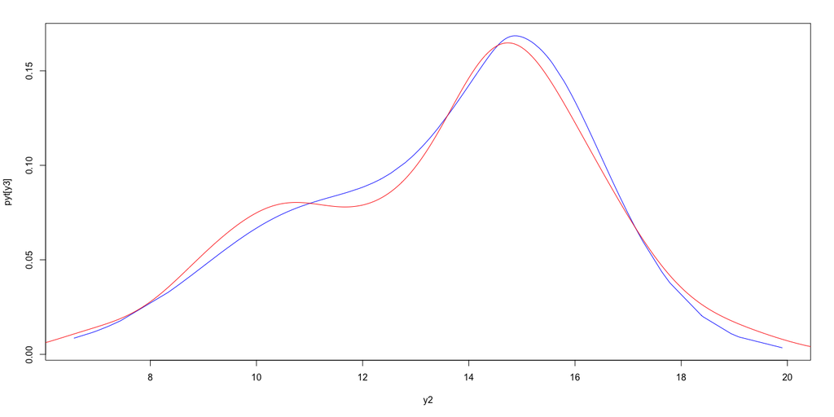

```r
y=0; n=200
for(t in 1:n) {
  if (runif(1,0,1) < 0.25) {
    y[t] = rnorm(1,10,sqrt(2))
    } else {
      y[t]=rnorm(1,15,sqrt(3))
      }
}
n = length(y)   # (for data sample)
kt = 1
omeg=rbeta(1,1,1)
for(k in 1:n) {
  if(runif(1,0,1)>0.5) {
    kt[k]=1
    } else {
      kt[k]=2
      }
  }  #some initial values for k
while(var(y[kt==2]) > var(y[kt==1])) {
  for(k in 1:n) {
    if(runif(1,0,1)>0.5) {
      kt[k]=1
    } else {
        kt[k]=2
        }
  }
}
mu1 = mean(y); sig1 = var(y)*1.5; d = 1000  # d = (MCMC sample size)
mu2 = mean(y); sig2 = var(y) * 0.5; mpkty = 0; pyt = 0; pyt2 = 0
for(k in 1:n) {
  mpkty[k]=0
  pyt[k]=0
  pyt2[k]=0
  }
pkymax = -99999; ktmax = kt
for(j in 2:d) {
  ktold=kt
  for(t in 1:n) {
    kt[t] = 1
    n1 = length(y[kt==1])
    n2 = n - n1
    y1 = y[kt==1] - mean(y[kt==1])
    y2 = y[kt==2] - mean(y[kt==2])

    ht1 = -0.5*(log(n1) + log(n2)) +
          lgamma((n1-1)/2) +
          lgamma((n2-1)/2)

    ht1 = ht1 -
          (n1 - 1)/2 * log(sum(y1^2)) -
          (n2-1)/2 * log(sum(y2^2))

    ht1 = ht1 +
          log(omeg[j-1])

    kt[t] = 2
    n1 = n1-1
    n2 = n2+1
    y1 = y[kt==1] -
         mean(y[kt==1])
    y2 = y[kt==2] -
         mean(y[kt==2])

    ht2 = -0.5 * (log(n1) + log(n2)) +
          lgamma((n1-1)/2) +
          lgamma((n2-1)/2)

    ht2 = ht2 -
          (n1-1)/2 * log(sum(y1^2)) -
          (n2-1)/2 * log(sum(y2^2))

    ht2 = ht2 +
          log(1 - omeg[j-1])

    pyk = 1/(1 + exp(ht2 - ht1))

    if(is.nan(pyk)) {
      if(is.nan(ht1)) {
        kt[t]=1
      }
      if(is.nan(ht2)) {
        kt[t]=2
        }
      } else {
        if(runif(1,0,1) < pyk) {
          kt[t] = 1
          pyt2[t] = pyt2[t] +
                    dnorm(y[t], mu1[j - 1], sqrt(sig1[j - 1]))
        } else {
            kt[t]=2
            pyt2[t] = pyt2[t] +
                      dnorm(y[t], mu2[j - 1], sqrt(sig2[j-1]))
            }
        mpkty[t] = mpkty[t] + pyk
      }

    n1 = length(kt[kt==1])

    if (n1 < 2 | n1 > (n - 3)) {
      kt[t] = ktold[t]
    }
    if (var(y[kt==2]) > var(y[kt==1])) {
      kt[t] = ktold[t]
    }
    pyt[t] = pyt[t] +
             omeg[j - 1] * dnorm(y[t], mu1[j - 1], sqrt(sig1[j - 1])) +
             (1-omeg[j-1]) * dnorm(y[t],mu2[j-1],sqrt(sig2[j-1]))
    }

  n1 = length(kt[kt==1])
  n2 = n-n1

  if(n1 < 2 | n1 > (n - 3) | var(y[kt==2]) > var(y[kt==1])) {
    kt = ktold
    n1 = length(kt[kt==1])
    n2 = n - n1
    }
  y1 = y[kt==1] -
       mean(y[kt==1])
  y2 = y[kt==2] -
       mean(y[kt==2])
  ht=-0.5*(log(n1)+log(n2)) + lgamma((n1-1)/2) + lgamma((n2-1)/2)
  ht=ht-(n1-1)/2*log(sum(y1^2))-(n2-1)/2*log(sum(y2^2))
  lpyk=ht
  c1=length(kt[kt==1]);c10= length(kt[kt==2])
  lpyk=lpyk+c1*log(omeg[j-1])+c10*log(1-omeg[j-1])
  if(j==1){pkymax=lpyk;ktmax=kt}else{
  if(lpyk>pkymax){pkymax=lpyk;ktmax=kt}}
  n1=length(y[kt==1]);n2=n-n1
  a=n1+1;b=n2+1;
          omeg[j]=rbeta(1,a,b)
          y1=y[kt==1];y2=y[kt==2]
          mu1[j]=rt(1,n1-1)*sqrt(var(y1)/n1)+mean(y1)
          mu2[j]=rt(1,n2-1)*sqrt(var(y2)/n2)+mean(y2)
          ymu=(y1-mu1[j])^2; D = sum(ymu)
          sig1[j]=1/rgamma(1,n1/2,D/2)
          ymu=(y2-mu2[j])^2; D = sum(ymu)
          sig2[j]=1/rgamma(1,n2/2,D/2)
          }
mpkty=mpkty/d
pyt=pyt/d; pyt2=pyt2/d
yi=sort(y,index.return=T)
y2=sort(y);
y3=yi[[2]]
plot(y2,pyt[y3],type='l',col=4)
lines(density(y),col=2)
```